# Week 6

## Quiz

1. Write a function to produce a bifurcation diagram for the `rate` parameter of the `pop_model` population model.
2. Perform a parameter reduction on the following model $$ f(n) = a^{-2}[b-f(n-2)]f(n-1). $$
3. What does the command `plt.subplot(a,b,c)` do?

### Answers

```python
def bifurcation(init_pop,time):
    para_vals = [i/25 for i in range(101)]  # 101 points between 0 and 4
    pop_vals = [pop_model(init_pop,i,time).pop(-1) for i in para_vals]
    plt.plot(para_vals,pop_vals)
```

$$ f(n) = a^{-2}[b-f(n-2)]f(n-1) $$$$ f(n)/b^2 = a^{-2}[b-f(n-2)]f(n-1)/b^2 $$$$ \frac{f(n)}{b} \frac{1}{b} = a^{-2}[1-\frac{f(n-2)}{b}]\frac{f(n-1)}{b} $$$$ g(n) \frac{1}{b} = a^{-2}[1-g(n-2)]g(n-1) $$$$ g(n) = \frac{b}{a^2}[1-g(n-2)]g(n-1) $$$$ g(n) = c[1-g(n-2)]g(n-1) $$

1. Subplot command creates an a-by-b grid of plots and places the current plot in position c.

## Notes

### Arrays and NumPy

```python
import numpy as np
```

```python
array1 = np.array([[1,2,3,4],[5,6,7,8],[9,10,11,12]])
print(array1)
```

```
[[ 1  2  3  4]
 [ 5  6  7  8]
 [ 9 10 11 12]]
```

```python
zeros1 = np.zeros((4,2))
print(zeros1)
```

```
[[0. 0.]
 [0. 0.]
 [0. 0.]
 [0. 0.]]
```

```python
zeros2 = np.zeros((4,2),dtype=int)
print(zeros2)
```

```
[[0 0]
 [0 0]
 [0 0]
 [0 0]]
```

```python
ones1 = np.ones((5,9),dtype=int)
print(ones1)
```

```
[[1 1 1 1 1 1 1 1 1]
 [1 1 1 1 1 1 1 1 1]
 [1 1 1 1 1 1 1 1 1]
 [1 1 1 1 1 1 1 1 1]
 [1 1 1 1 1 1 1 1 1]]
```

```python
array1[1,2]
```

```
7
```

```python
array1[1,1:3]
```

```
array([6, 7])
```

```python
array1[1,1:]
```

```
array([6, 7, 8])
```

```python
array1[:2,2]
```

```
array([3, 7])
```

```python
array1[:2,1:]
```

```
array([[2, 3, 4],
       [6, 7, 8]])
```

```python
np.shape(array1[:2,1:])
```

```
(2, 3)
```

```python
array1[0:3,2]
```

```
array([ 3,  7, 11])
```

```python
array1[:,2]
```

```
array([ 3,  7, 11])
```

```python
array1[:np.shape(array1)[0]//2,:np.shape(array1)[1]//2]
```

```
array([[1, 2]])
```

```python
m,n = np.shape(array1)
array1[:m//2,:n//2]
```

```
array([[1, 2]])
```

```python
ones1[:4,:2] = zeros2
print(ones1)
```

```
[[0 0 1 1 1 1 1 1 1]
 [0 0 1 1 1 1 1 1 1]
 [0 0 1 1 1 1 1 1 1]
 [0 0 1 1 1 1 1 1 1]
 [1 1 1 1 1 1 1 1 1]]
```

```python
ones1[-3:,-4:] = array1
print(ones1)
```

```
[[ 0  0  1  1  1  1  1  1  1]
 [ 0  0  1  1  1  1  1  1  1]
 [ 0  0  1  1  1  1  2  3  4]
 [ 0  0  1  1  1  5  6  7  8]
 [ 1  1  1  1  1  9 10 11 12]]
```

```python
array1[[1,2],[0,2]]
```

```
array([ 5, 11])
```

```python
array2 = np.transpose(array1)
print(array1)
print(array2)
```

```
[[ 1  2  3  4]
 [ 5  6  7  8]
 [ 9 10 11 12]]
[[ 1  5  9]
 [ 2  6 10]
 [ 3  7 11]
 [ 4  8 12]]
```

```python
3*np.concatenate([array2,zeros2],axis=1)
```

```
array([[ 3, 15, 27,  0,  0],
       [ 6, 18, 30,  0,  0],
       [ 9, 21, 33,  0,  0],
       [12, 24, 36,  0,  0]])
```

Create an array of horizontal stripes (each consisting of 2 rows) of integers. Each stripe should be 10 wide. The first stripe should have value 0, the second should have value 1, third, value 2, etc. Make 5 stripes.

Strategy 1:

- First create all the stripes separately
  - for the zero stripe use np.zeros((2,10))
  - manually create the other stipes
  - scale an array of all ones to get the other stipes
- Then concatenate into a single array

```python
np.concatenate([i*np.ones((2,10),dtype=int) for i in range(5)],axis=0)
```

```
array([[0, 0, 0, 0, 0, 0, 0, 0, 0, 0],
       [0, 0, 0, 0, 0, 0, 0, 0, 0, 0],
       [1, 1, 1, 1, 1, 1, 1, 1, 1, 1],
       [1, 1, 1, 1, 1, 1, 1, 1, 1, 1],
       [2, 2, 2, 2, 2, 2, 2, 2, 2, 2],
       [2, 2, 2, 2, 2, 2, 2, 2, 2, 2],
       [3, 3, 3, 3, 3, 3, 3, 3, 3, 3],
       [3, 3, 3, 3, 3, 3, 3, 3, 3, 3],
       [4, 4, 4, 4, 4, 4, 4, 4, 4, 4],
       [4, 4, 4, 4, 4, 4, 4, 4, 4, 4]])
```

Strategy 2:

- Start with an array of all zeros
- Broadcast in each of the stripes
  - for the zero stripe use np.zeros((2,10))
  - manually create the other stipes
  - scale an array of all ones to get the other stipes

```python
A = np.zeros((10,10),dtype=int)
for i in range(5):
    A[2*i:2*i+2,:] = i*np.ones((2,10),dtype=int)
A
```

```
array([[0, 0, 0, 0, 0, 0, 0, 0, 0, 0],
       [0, 0, 0, 0, 0, 0, 0, 0, 0, 0],
       [1, 1, 1, 1, 1, 1, 1, 1, 1, 1],
       [1, 1, 1, 1, 1, 1, 1, 1, 1, 1],
       [2, 2, 2, 2, 2, 2, 2, 2, 2, 2],
       [2, 2, 2, 2, 2, 2, 2, 2, 2, 2],
       [3, 3, 3, 3, 3, 3, 3, 3, 3, 3],
       [3, 3, 3, 3, 3, 3, 3, 3, 3, 3],
       [4, 4, 4, 4, 4, 4, 4, 4, 4, 4],
       [4, 4, 4, 4, 4, 4, 4, 4, 4, 4]])
```

```python
import matplotlib.pyplot as plt
```

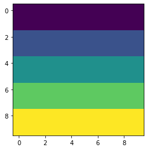

```python
plt.imshow(A)
```